# Assignment 2

Hoa Cao

19/10/2021

###Exploration and visualization of data

This step is based on a class workshop and uses “rweet” package

1. Present the first 10 tweets from your dataset using `kable()`. Use `kable()` in all steps to present the tabular data

```r
knitr::kable(tweets[1:10,1:8])
```

[output not shown]

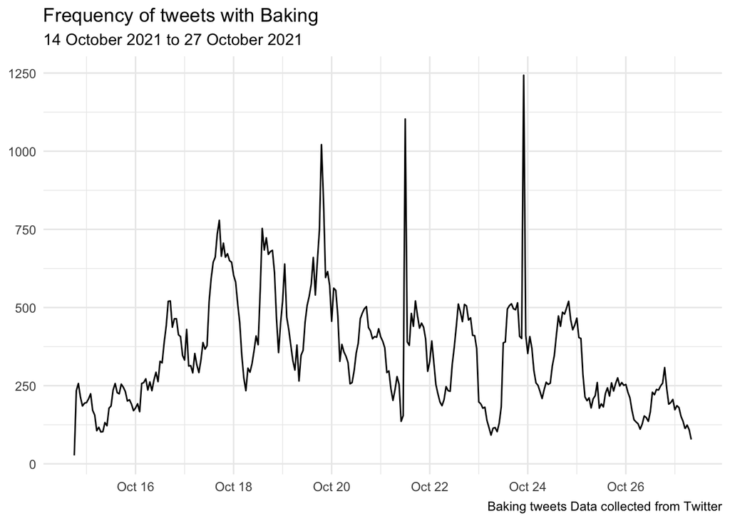

```r
ts_plot(tweets, "hours") +
  labs(x = NULL, y = NULL,
       title = "Frequency of tweets with Baking ",
       subtitle = paste0(format(min(tweets$created_at), "%d %B %Y"), " to ", format(max(tweets$created_at),"%d %B %Y")),
       caption = "Baking tweets Data collected from Twitter") +
  theme_minimal()
```

3. Identify top tweeting locations and present the first 10. Write 2-3 sentences on your insights from this.

```r
tweets %>%
  filter(!is.na(place_full_name)) %>%
  count(place_full_name, sort = TRUE) %>%
  top_n(10)
```

```
## # A tibble: 15 × 2
##    place_full_name              n
##    <chr>                    <int>
##  1 Los Angeles, CA             61
##  2 Chicago, IL                 39
##  3 Manhattan, NY               26
##  4 Dearne, England             23
##  5 Auckland, New Zealand       22
##  6 Stockholm, Sweden           22
##  7 San Diego, CA               20
##  8 Austin, TX                  17
##  9 Scotland, United Kingdom    17
## 10 Birmingham, England         15
## 11 Brooklyn, NY                15
## 12 Florida, USA                15
## 13 San Francisco, CA           15
## 14 Seattle, WA                 15
## 15 Washington, DC              15
```

#Insights: The most popular tweeting location is Los Angeles, CA, followed by Chicago, IL , and Manhattan, NY. Therefore, Los Angeles is potential place to approach target customers, partners in baking industry.

```r
tweets %>%
  arrange(-retweet_count) %>%
  slice(1) %>%
  select(created_at, screen_name, text, retweet_count) %>%
  top_n(20)
```

```
## # A tibble: 1 × 4
##   created_at          screen_name  text                            retweet_count
##   <dttm>              <chr>        <chr>                                   <dbl>
## 1 2021-10-15 03:17:58 bestrollever "🥐🍞🥖🐱✨ \nNow baking; welc…          2301
```

5. Identify the most liked tweets and present the first 15. Write 2-3 sentences on your insights from this

```r
tweets %>%
  arrange(-favorite_count) %>%
  top_n(15, favorite_count) %>%
  select(created_at, screen_name, text, favorite_count)
```

```
## # A tibble: 15 × 4
##    created_at          screen_name    text                        favorite_count
##    <dttm>              <chr>          <chr>                                <dbl>
##  1 2021-10-24 02:25:56 16pxl          "i rly love baking focacci…          12433
##  2 2021-10-24 02:25:56 16pxl          "i rly love baking focacci…          11812
##  3 2021-10-24 06:30:51 bitsbyt3s      "Baking\n\n#dsmpfanart #ni…          10306
##  4 2021-10-15 03:17:58 bestrollever   "🥐🍞🥖🐱✨ \nNow baking; …          10265
##  5 2021-10-14 23:30:34 takanashikiara "I gotta get up super earl…          10071
##  6 2021-10-24 06:30:51 bitsbyt3s      "Baking\n\n#dsmpfanart #ni…           9875
##  7 2021-10-22 20:29:12 Nihaachu       "I AM BAKING SO MANY THING…           9750
##  8 2021-10-23 22:37:42 GNFUPDATES     "George says he’ll be stre…           9183
##  9 2021-10-23 22:37:42 GNFUPDATES     "George says he’ll be stre…           9070
## 10 2021-10-20 15:39:12 annoyingaria   "Morning 🥺 see u guys tod…           7350
## 11 2021-10-20 15:39:12 annoyingaria   "Morning 🥺 see u guys tod…           6588
## 12 2021-10-16 21:58:01 asdfghjkiri    "#EIJIROCTOBER2021 Day 16:…           3729
## 13 2021-10-16 21:58:01 asdfghjkiri    "#EIJIROCTOBER2021 Day 16:…           3623
## 14 2021-10-21 12:17:59 petrigogy      "#GEORGE: baking stream fo…           3609
## 15 2021-10-21 12:17:59 petrigogy      "#GEORGE: baking stream fo…           3591
```

```r
tweets %>%
  count(screen_name, sort = TRUE) %>%
  top_n(5) %>%
  mutate(screen_name = paste0("@", screen_name))
```

```
## # A tibble: 5 × 2
##   screen_name         n
##   <chr>           <int>
## 1 @nutralift2       774
## 2 @NannaBettySays   438
## 3 @MrFrog83419022   403
## 4 @bakednet         294
## 5 @BritBakeBot      286
```

#Insights: We can follow these tweeters to see the trends as well as learn from these tweeters topics, keywords to attract more followers. 7. Identify top emojis in your dataset and present the first 10.

```r
library(emo)
tweets %>%
  mutate(emoji = ji_extract_all(text)) %>%
  unnest(cols = c(emoji)) %>%
  count(emoji, sort = TRUE) %>%
  top_n(10)
```

```
## # A tibble: 10 × 2
##    emoji     n
##    <chr> <int>
##  1 😂     3010
##  2 😭     2605
##  3 🤣     1907
##  4 😋     1431
##  5 ❤️      1338
##  6 🥰     1315
##  7 😍     1124
##  8 🎃     1104
##  9 🥺      954
## 10 🍪      905
```

8. Identify top hashtags in your dataset and present the first 10. Write 2-3 sentences on your insights from this

```r
library(tidytext)
tweets %>%
  unnest_tokens(hashtag, text, "tweets", to_lower = FALSE) %>%
  filter(str_detect(hashtag, "^#"),
        hashtag != "#Baking") %>%
  count(hashtag, sort = TRUE) %>%
  top_n(10)
```

```
## # A tibble: 11 × 2
##    hashtag             n
##    <chr>           <int>
##  1 #baking          5910
##  2 #recipes         1325
##  3 #bread           1112
##  4 #cupcakes         990
##  5 #cakedecorating   982
##  6 #pastry           937
##  7 #GBBO             863
##  8 #gifts            844
##  9 #gourmetfood      830
## 10 #candles          827
## 11 #giftshop         827
```

#Insights: I will use these hashtag such as #baking, #recipes, #bread in my post to approach more view to my post. 9. Identify top mentions in your dataset and present the first 10. Write 2-3 sentences on your insights from this

```r
tweets %>%
  unnest_tokens(mentions, text, "tweets", to_lower = FALSE) %>%
  filter(str_detect(mentions, "^@")) %>%
  count(mentions, sort = TRUE) %>%
  top_n(10)
```

```
## # A tibble: 10 × 2
##    mentions             n
##    <chr>            <int>
##  1 @Etsy              459
##  2 @saracarrion       384
##  3 @tonyposnanski     288
##  4 @bakinghomo        259
##  5 @BritishBakeOff    253
##  6 @StandardBankZA    249
##  7 @adbaking          209
##  8 @Wrightsbaking     169
##  9 @HubertSS          165
## 10 @insighteditions   161
```

#Insights: These top mentions show the name of website, app, company. I can find baking items, baking products from these mention. As can be seen from the top list, etsy will be good place to find baking items.  
10. Get a list of all accounts that the top tweeter follows and present the first 5

```r
get_friends("nutralift2") %>%
top_n(5)
```

```
## # A tibble: 5 × 2
##   user       user_id
##   <chr>      <chr>
## 1 nutralift2 99954968
## 2 nutralift2 994250736
## 3 nutralift2 997684836
## 4 nutralift2 99340528
## 5 nutralift2 996107408
```

11. Get a list of followers of the top tweeter and present the first 5

```r
get_followers("nutralift2", n=75000) %>%
top_n(5)
```

```
## # A tibble: 5 × 1
##   user_id
##   <chr>
## 1 999760320745934854
## 2 999010689355149313
## 3 99930317
## 4 998961794
## 5 998817710
```

### Topic modeling and visualization

```r
library(tidytext)
library(tidyverse)
library(lubridate)
```

```r
library(textdata)

library(RColorBrewer)
library(wordcloud)
library(wordcloud2)

library(topicmodels)
library(tm)
tweet<-read_csv("New_Final_Data_Baking.csv")
tweet<-
  tweet%>%
  mutate(
    timestamp=ymd_hms(created_at),
    day_of_week=wday(timestamp),
    id=as_factor(row_number())
  )
```

#explore wday() function

```r
remove_reg <- "&amp;|&lt;|&gt;|\\d+\\w*\\d*|#\\w+|[^\x01-\x7F]|[[:punct:]]|https\\S*"
# &amp = @
# &lt;= <
# &gt; >
```

#removing retweets characters

```r
tidy_tweets <- tweet %>%
  filter(!str_detect(text, "^RT")) %>%
  mutate(text = str_remove_all(text, remove_reg))
```

#unnesting tweets

```r
tidy_tweets<-tidy_tweets%>%
  unnest_tokens(word, text, token = "tweets")
```

```
## Using `to_lower = TRUE` with `token = 'tweets'` may not preserve URLs.
```

# Remove mentions, urls, emojis, numbers, punctuations, etc.

```r
tidy_tweets<-tidy_tweets%>%
  filter(
    str_detect(word, "[a-z]")#keep only character-words
    )%>%
  anti_join((stop_words))
head(tidy_tweets$word)
```

```
## [1] "chennpug" "smitten"  "kitchen"  "david"    "lebovitz" "baking"
```

#topic modeling

#create a document term frequency based on how often words are

```r
tweets_dtm<-tidy_tweets%>%
  count(id, word)%>%
  cast_dtm( #converts our data to a special object for R = document term frequency matrix
    document=id,
    term=word,
    value=n,
    weighting=tm::weightTf
    )

tweets_dtm
```

```
## <<DocumentTermMatrix (documents: 106042, terms: 66816)>>
## Non-/sparse entries: 998514/7084303758
## Sparsity           : 100%
## Maximal term length: 99
## Weighting          : term frequency (tf)
```

#to speed up processing let’s remove those words that are VERY rare #sparse=rare

```r
#install.packages("tm")
tweets_dtm_trim<-tm::removeSparseTerms(tweets_dtm, sparse=.99)
rowTotals <- apply(tweets_dtm_trim, 1, sum) #Find the sum of words in each Document
tweets_dtm_trim <- tweets_dtm_trim[rowTotals> 0, ]

tweets_dtm_trim
```

```
## <<DocumentTermMatrix (documents: 102026, terms: 77)>>
## Non-/sparse entries: 264536/7591466
## Sparsity           : 97%
## Maximal term length: 11
## Weighting          : term frequency (tf)
```

#LDA for 5 topics

```r
tweets_lda<-LDA(tweets_dtm_trim, k=5, control=list(seed=1234))

tweet_topics<-tidy(tweets_lda, matrix="beta")
```

```r
library("tm")
library("topicmodels")
```

#let’s look at them with 10 top words for each topic

```r
tweet_top_terms <- tweet_topics %>%
  group_by(topic) %>%
  top_n(10, beta) %>%
  ungroup() %>%
  arrange(topic, -beta)
```

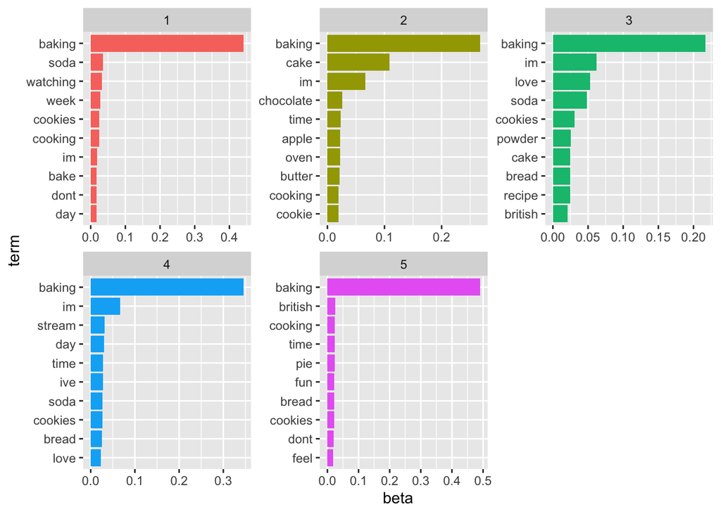

```r
tweet_top_terms %>%
  mutate(term = reorder_within(term, beta, topic)) %>%
  ggplot(aes(term, beta, fill = factor(topic))) +
  geom_col(show.legend = FALSE) +
  facet_wrap(~ topic, scales = "free") +
  coord_flip() +
  scale_x_reordered()
```

#LDA models identify the words that are most frequently associated with topics specified by the user. #Conclustion: The data of my topic shows amazing information for research. From this information, I can find trends, key words, as well as learn from best tweeters for my future tweets.